# Statistics for the worst and performing breakdown groups across Facebook ads

Rick Pack

2018-02-06

The `fbadGstats` function aggregates across all of the Facebook (FB) ads performance data one provides from FB Ads Manager and indicates the best and worst performers per subgroup / breakdown group. *Disclaimer: This function and the entire `FBadstats` package are not supported or endorsed by Facebook, Inc. Only the user is responsible for its use.*

# How to use `fbadGstats`

## Easiest use - select a file or folder

The easiest use is available only in Windows. Call the function, navigate to your exported CSV file and then select it. The default parameters may give you all you need.  
Background: Running the function without a `filerd` parameter will prompt you with a window in which you choose your CSV file, and then the default parameters for `fbadGstats` are used. ### Call the function

```r
fbadGstats()
```

### Select your file

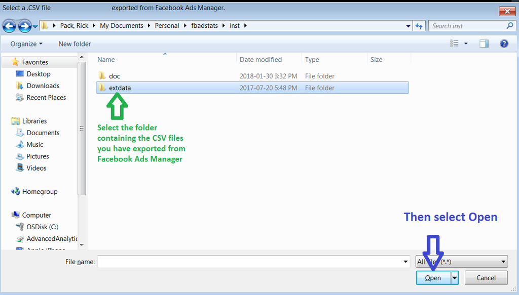

Windows Explorer file-selection

### Use the output

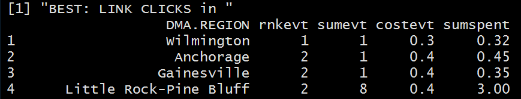

Portion of fbadGstats output

[Windows-Only] Running the function with `choosedir` set to “YES” prompts you with a window in which you can select a folder and `fbadgstats` runs on every .CSV file in that directory / folder.

```r
fbadGstats(choosedir="YES")
```

## Advanced use - use one of the >10 parameters

We will first use the included **example_PerfClk_AgeGender** CSV file that represents exported data from ads dedicated to acquiring “Leads” (email addresses for potential customers AKA “an email funnel”).

The “PerfClk” in the name indicates that the “Performance and Clicks” view was used in Ads Manager at the time of the export, which is the best view to first try - others may fail. I will add to the error messages over time so one better understands why a view failed, and a view may succeed as the function evolves. The “AgeGender” in the filename expresses that the selected breakdown was a *combination* of age and gender.

### Show only the table output (not a graph and its complementing table):

Setting the `tblout` parameter to BOTH causes the best and worst performers to appear in the table **Note:** The filerd parameter, if used, must have the full path to a CSV file with slashes, not backslashes (e.g., `filerd` = *‘c:/users/Users/RickPack/Documents/R/LeadData.csv’*). Example files included with the `FBadstats` package are exceptions.

### now call the function and provide parameters as desired

```r
fbadGstats(filerd = "example_PerfClk_AgeGender.csv", grphout = "NO", tblout = "BOTH")
```

[output not shown]

### Show only the best breakdown groups in the table:

**Note:** `fbadGstats` graphs *always* show only the best breakdown groups.

```r
fbadGstats(filerd = "example_PerfClk_AgeGender.csv", grphout = "YES", tblout = "BEST")
```

```
#> [1] "-------------------------------------------------------------"
#> [1] "BEST: RESULTS in example_PerfClk_AgeGender.csv"
#>      AGE_GENDER rnkevt sumevt costevt sumspent
#> 1    35-44:male      1     11     0.2     2.34
#> 2    25-34:male      2      2     0.7     1.49
#> 3  18-24:female      3     10     0.8     8.42
#> 4 35-44:unknown      4      1     0.9     0.91
#> 5  55-64:female      5     34     1.2    40.84
#> 6  25-34:female      6     71     1.5   103.02
#> 7  35-44:female      6    108     1.5   164.20
#> 8  45-54:female      6     41     1.5    62.28
#> [1] "Number of groups in all of data: 14"
#> [1] "Number of AGE_GENDER groups with at least one RESULTS and minimum spend of $0 = 8"
#> [1] "Total amount spent: $384.38"
```

[figure not shown]

### Parameter highlight: `spentlim`

I enjoy exploring DMAs (Designated Market Areas) as targets for advertising. Let’s look at the worst performers.

```r
fbadGstats(filerd = "example_DMA.csv", grphout = "NO", tblout = "WORST")
```

```
#> [1] "-------------------------------------------------------------"
#> [1] "WORST: LINK CLICKS in example_DMA.csv"
#>                    DMA.REGION rnkevt sumevt costevt sumspent
#> 1        Miami-Ft. Lauderdale     63      1     5.4     5.38
#> 2    Cleveland-Akron (Canton)     62      1     4.1     4.06
#> 3                   Nashville     61      1     4.0     4.05
#> 4                Jacksonville     60      1     3.8     3.79
#> 5         Boston (Manchester)     59      1     2.9     2.89
#> 6                    New York     57      6     2.5    15.12
#> 7                 San Antonio     57      1     2.5     2.46
#> 8                     Chicago     56      6     2.4    14.28
#> 9                     Atlanta     53     12     2.3    27.54
#> 10 Raleigh-Durham (Fayetvlle)     53      6     2.3    14.06
#> 11                   Savannah     53      1     2.3     2.31
#> 12                    Houston     51      7     2.2    15.54
#> 13               Indianapolis     51      2     2.2     4.49
#> 14               Columbia, SC     48      2     2.1     4.13
#> 15                    Memphis     48      3     2.1     6.35
#> 16 Norfolk-Portsmth-Newpt Nws     48      3     2.1     6.40
#> 17                     Austin     46      1     2.0     1.99
#> 18                      Macon     46      1     2.0     2.04
#> 19                     Dayton     45      1     1.9     1.88
#> 20                    Detroit     41      5     1.8     9.25
#> [1] "Number of groups in all of data: 135"
#> [1] "Number of DMA REGION groups with at least one LINK CLICKS and minimum spend of $0 = 63"
#> [1] "Total amount spent: $320.47"
```

Look at all the regions with small amounts spent on them like #19 *Dayton* ($1.88). Perhaps not enough money has been spent in those regions, at least yet, to make their exclusion worthwhile.

We can use the `spentlim` parameter to specify a minimum amount spent and therefore capture the DMAs that are proportionally more wasteful. By setting the minimum spent to $5, DMAs including *Dayton* no longer appear and *New York* rises to the second worst slot.

```r
fbadGstats(filerd = "example_DMA.csv", grphout = "NO", tblout = "WORST", spentlim = 5)
```

```
#> [1] "-------------------------------------------------------------"
#> [1] "WORST: LINK CLICKS in example_DMA.csv"
#>                    DMA.REGION rnkevt sumevt costevt sumspent
#> 1        Miami-Ft. Lauderdale     18      1     5.4     5.38
#> 2                    New York     17      6     2.5    15.12
#> 3                     Chicago     16      6     2.4    14.28
#> 4                     Atlanta     14     12     2.3    27.54
#> 5  Raleigh-Durham (Fayetvlle)     14      6     2.3    14.06
#> 6                     Houston     13      7     2.2    15.54
#> 7                     Memphis     11      3     2.1     6.35
#> 8  Norfolk-Portsmth-Newpt Nws     11      3     2.1     6.40
#> 9                     Detroit      9      5     1.8     9.25
#> 10               Philadelphia      9      3     1.8     5.55
#> 11 Orlando-Daytona Bch-Melbrn      8      3     1.7     5.22
#> 12 Greensboro-H.Point-W.Salem      7      4     1.6     6.50
#> 13                  Charlotte      6      7     1.5    10.29
#> 14                  Baltimore      5      5     1.4     6.82
#> 15  Washington, DC (Hagrstwn)      4      4     1.3     5.14
#> 16           Dallas-Ft. Worth      2     12     1.2    13.89
#> 17                Los Angeles      2      9     1.2    10.36
#> 18  Birmingham (Ann And Tusc)      1      6     1.1     6.49
#> [1] "Number of groups in all of data: 135"
#> [1] "Number of DMA REGION groups with at least one LINK CLICKS and minimum spend of $5 = 18"
#> [1] "Total amount spent: $320.47"
```

### Parameter highlight: `prtrow`, `minevent`, `sumvar`

Finally, the 15 worst with respect to *WEBSITE.REGISTRATIONS.COMPLETED* using the `sumvar` parameter. Notice that the entire column entry does not need to be typed for this case-insensitive parameter. “Regist” was sufficient. No limit on the amount spent (i.e., no `minspent` paramter in function call) but at least two *WEBSITE.REGISTRATIONS.COMPLETED* must have occurred:

```r
fbadGstats(filerd = "example_DMA.csv", grphout = "NO", tblout = "WORST", sumvar = "Regist", prtrow = 15, minevent = 2)
```

```
#> [1] "-------------------------------------------------------------"
#> [1] "WORST: WEBSITE REGISTRATIONS COMPLETED in example_DMA.csv"
#>                    DMA.REGION rnkevt sumevt costevt sumspent
#> 1                     Chicago     21      6     2.4    14.28
#> 2                 Los Angeles     19      5     2.1    10.36
#> 3  Norfolk-Portsmth-Newpt Nws     19      3     2.1     6.40
#> 4                     Atlanta     18     14     2.0    27.54
#> 5            Dallas-Ft. Worth     16      8     1.7    13.89
#> 6  Orlando-Daytona Bch-Melbrn     16      3     1.7     5.22
#> 7  Greensboro-H.Point-W.Salem     15      4     1.6     6.50
#> 8                     Detroit     14      6     1.5     9.25
#> 9                Columbia, SC     13      3     1.4     4.13
#> 10  Birmingham (Ann And Tusc)     12      6     1.1     6.49
#> 11             Seattle-Tacoma     11      3     1.0     2.98
#> 12              Augusta-Aiken     10      3     0.9     2.82
#> 13                  Charlotte      8     13     0.8    10.29
#> 14 Raleigh-Durham (Fayetvlle)      8     17     0.8    14.06
#> 15  Washington, DC (Hagrstwn)      7      7     0.7     5.14
#> [1] "Number of groups in all of data: 135"
#> [1] "Number of DMA REGION groups with at least one WEBSITE REGISTRATIONS COMPLETED and minimum spend of $0 = 21"
#> [1] "Total amount spent: $320.47"
```